# Default of Credit Card Clients: Data Loading and Exploratory Data Analysis

Alex Jones and Hudson Plaskoff

2026-04-02

## Introduction

The Default of Credit Card Clients dataset from the UC Irvine Machine Learning Repository was originally published in 2016. This dataset contains data concerning default payments of individuals in Taiwan, including if the next credit card payment was paid or defaulted upon. It also contains data about each individual’s level of education, marriage status, the dollar value of credit card statements for a given month, and more. The dataset’s sample size is 30,000, meaning that 30,000 people’s credit information were used in making this dataset.

The dataset can be accessed here: https://archive.ics.uci.edu/dataset/350/default+of+credit+card+clients

## Data Import

```r
ccdata <- read_excel("default of credit card clients.xls", skip=1) %>%
  rename(
    CREDIT = LIMIT_BAL,
    REPAYMENT_2006_09 = PAY_0,
    REPAYMENT_2006_08 = PAY_2,
    REPAYMENT_2006_07 = PAY_3,
    REPAYMENT_2006_06 = PAY_4,
    REPAYMENT_2006_05 = PAY_5,
    REPAYMENT_2006_04 = PAY_6,
    STATEMENT_2006_09 = BILL_AMT1,
    STATEMENT_2006_08 = BILL_AMT2,
    STATEMENT_2006_07 = BILL_AMT3,
    STATEMENT_2006_06 = BILL_AMT4,
    STATEMENT_2006_05 = BILL_AMT5,
    STATEMENT_2006_04 = BILL_AMT6,
    LASTPAYMENT_2006_09 = PAY_AMT1,
    LASTPAYMENT_2006_08 = PAY_AMT2,
    LASTPAYMENT_2006_07 = PAY_AMT3,
    LASTPAYMENT_2006_06 = PAY_AMT4,
    LASTPAYMENT_2006_05 = PAY_AMT5,
    LASTPAYMENT_2006_04 = PAY_AMT6,
    NEXT_PAYMENT = "default payment next month"
  ) %>%
  mutate(
    EDUCATION = case_when(
      EDUCATION == 1        ~ "graduate_degree",
      EDUCATION == 2        ~ "undergraduate_degree",
      EDUCATION == 3        ~ "high_school",
      .default = "other"
    )
  ) %>%
  mutate(
    SEX = case_when(
      SEX == 1        ~ "male",
      SEX == 2        ~ "female"
    )
  ) %>%
  mutate(
    MARRIAGE = case_when(
      MARRIAGE == 1    ~ "married",
      MARRIAGE == 2    ~ "single",
      MARRIAGE == 3    ~ "other"
    )
  ) %>%
  mutate(
    NEXT_PAYMENT = case_when(
      NEXT_PAYMENT == 1    ~ "paid",
      NEXT_PAYMENT == 0    ~ "defaulted",
    )
  )
```

In order to import the data, we first had to utilize a different library than usual (readxl) because the dataset was stored in a XSL file rather than a CSV file. Otherwise put, R Studio didn’t recognize how to read the file in the way it typically does, so we had to use a different approach.

Next, we renamed some of the variable names using context provided by the description of the dataset in order for it to make more sense by itself. This mainly meant renaming the series of variables beginning with “PAY”, “BILL_AMT”, and “PAY_AMT” so that they could be understood by someone looking at this dataset alone and not having access to any other information.

Lastly, we performed a conditional transformation on four of the variables, meaning that we converted their numerical data (which represented categorical data) to explicit categorical data. An example of this is “2” in education indicating that a given individual has an undergraduate degree. One issue that required more consideration was the presence of both “4”s (which indicated “other”) and other values (not 1, 2, 3, or 4) that resulted in NAs when we strictly set four types for education, which we resolved by combining these two into a single “other” category. These transformations allow for better analysis in future steps.

# Univariate Data

## Credit

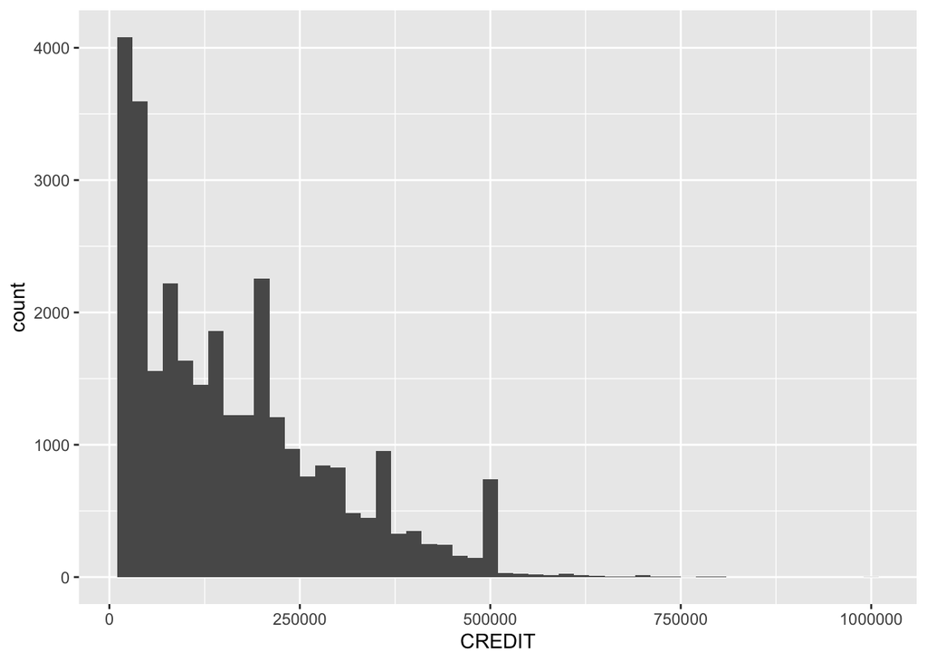

```r
ggplot(ccdata,aes(x=CREDIT)) + geom_histogram(binwidth=20000)
```

```r
ccdata_credit <- ccdata %>%
  summarize(
    min_credit = min(CREDIT),
    mean_credit = mean(CREDIT),
    median_credit = median(CREDIT),
    max_credit = max(CREDIT),
    sd_credit = sd(CREDIT)
  )

knitr::kable(ccdata_credit)
```

| min_credit | mean_credit | median_credit | max_credit | sd_credit |
| --- | --- | --- | --- | --- |
| 10000 | 167484.3 | 140000 | 1e+06 | 129747.7 |

There are more observations of individuals with lower credit than there are with higher credit. This is shown in the histogram, as well as by the mean and median of credit, which indicate that an individual’s credit is low on average. The standard deviation indicates that the observations of credit are not highly concentrated around the mean or median, and that they instead are more spread out. This is also shown by the minimum credit observed of 10,000 and the maximum credit observed of 1,000,000. Although these outliers do exist, a vast majority of individuals did not have credit above 500,000.

## Age

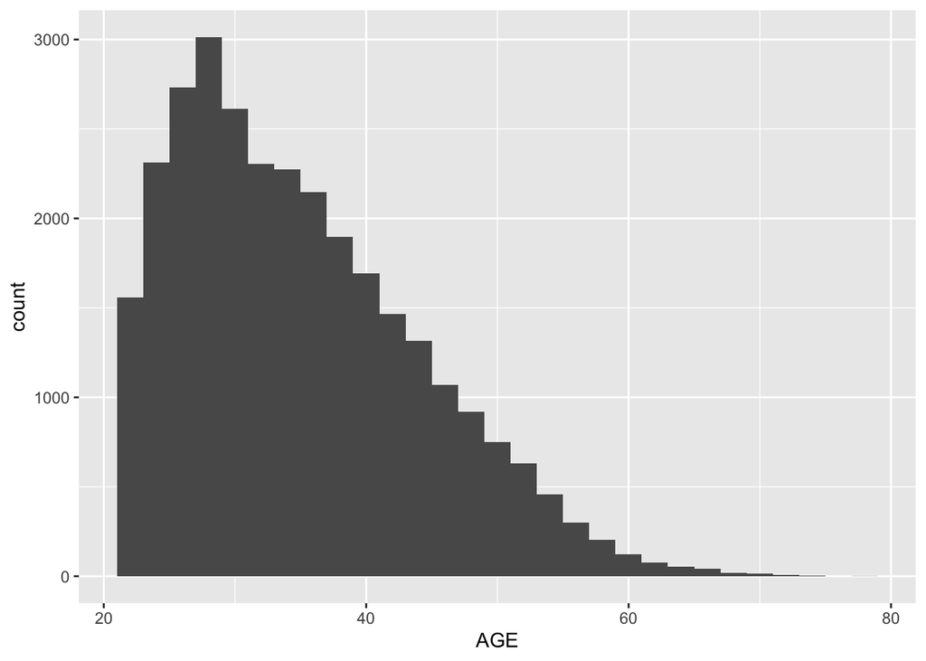

```r
ggplot(ccdata,aes(x=AGE)) + geom_histogram(binwidth=2)
```

```r
ccdata_age <- ccdata %>%
  summarize(
    min_age = min(AGE),
    mean_age = mean(AGE),
    median_age = median(AGE),
    max_age = max(AGE),
    sd_age = sd(AGE)
  )

knitr::kable(ccdata_age)
```

| min_age | mean_age | median_age | max_age | sd_age |
| --- | --- | --- | --- | --- |
| 21 | 35.4855 | 34 | 79 | 9.217904 |

The average individual in this dataset is roughly 34 to 35 years old, as indicated by the mean age of 35.4855 and the median age of 34. The minimum age is 21 and the maximium age is 79, which in this context means that there were no observed individuals with credit outside of this age range. The lower standard deviation reveals that there is a moderate concentration of individuals near the average age, although there are still some notable observations outside of this range.

## Education

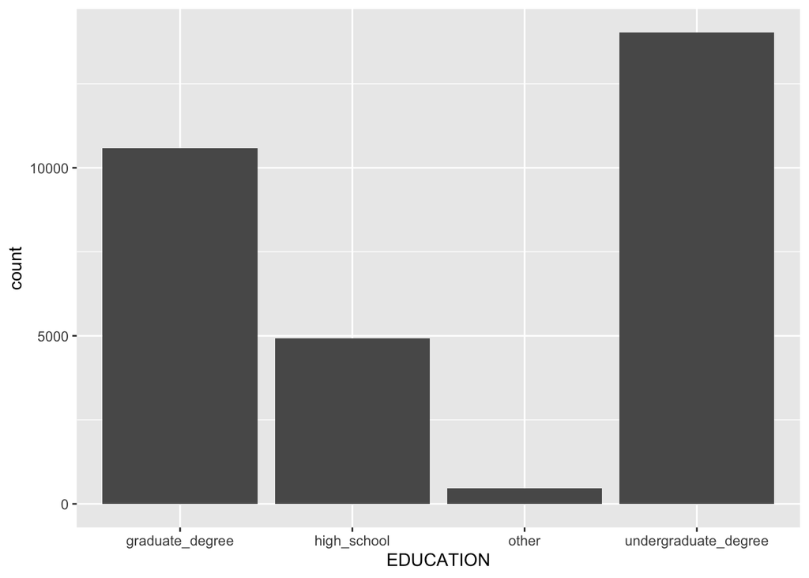

```r
ggplot(ccdata,aes(x=EDUCATION)) + geom_bar()
```

```r
ccdata_education <- ccdata %>%
  group_by(EDUCATION) %>%
  summarize(
    n = n()
  ) %>%
  mutate(
    prop = n/sum(n)
  )

knitr::kable(ccdata_education)
```

| EDUCATION | n | prop |
| --- | --- | --- |
| graduate_degree | 10585 | 0.3528333 |
| high_school | 4917 | 0.1639000 |
| other | 468 | 0.0156000 |
| undergraduate_degree | 14030 | 0.4676667 |

The data reveals that most of the people observed with credit have an undergraduate (46.76%) or graduate degree (35.28%). There are also individuals with credit that did not have a college degree, as seen by those with high school degrees (16.39%) and those who did not fall into any of these categories (1.56%).

# Bivariate Data

## Education and Credit

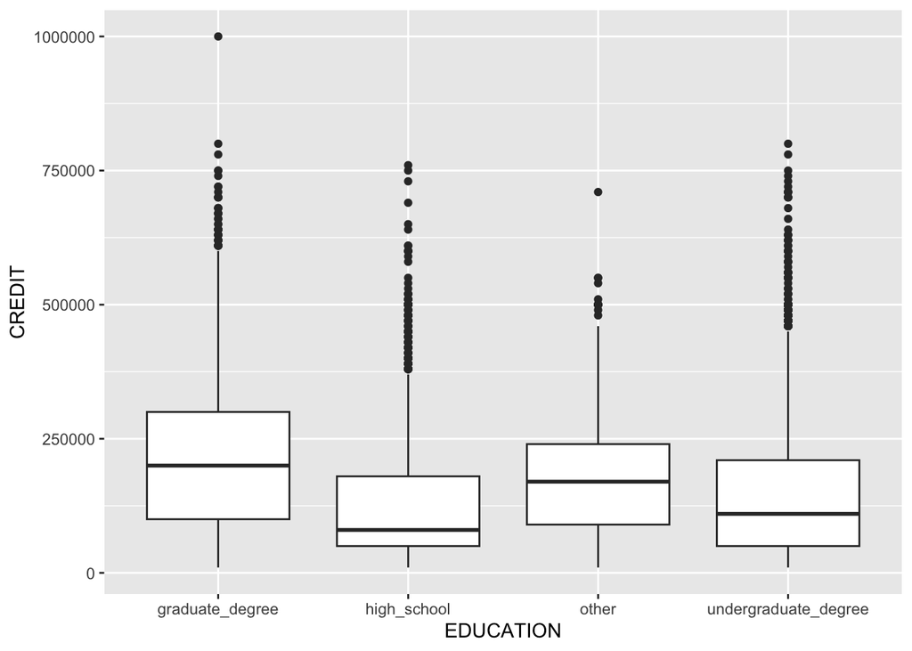

```r
ggplot(ccdata, aes(x = EDUCATION, y = CREDIT)) +
  geom_boxplot()
```

```r
ccdata_credit_by_education <- ccdata %>%
  group_by(EDUCATION) %>%
  summarize(
    mean_credit = mean(CREDIT),
    median_credit = median(CREDIT),
    sd_credit = sd(CREDIT),
    n = n()
  )

knitr::kable(ccdata_credit_by_education %>% head())
```

| EDUCATION | mean_credit | median_credit | sd_credit | n |
| --- | --- | --- | --- | --- |
| graduate_degree | 212956.1 | 200000 | 135474.9 | 10585 |
| high_school | 126550.3 | 80000 | 113979.3 | 4917 |
| other | 181316.2 | 170000 | 118385.7 | 468 |
| undergraduate_degree | 147062.4 | 110000 | 120672.3 | 14030 |

The data shows that those with higher education levels have higher credit on average than those with lower credit. This is also shown for those with education marked as “other”, but the small sample size for this category means it can be heavily skewed by outliers, as indicated by the substantial standard deviation of credit that remains in each category.

## Age and Credit

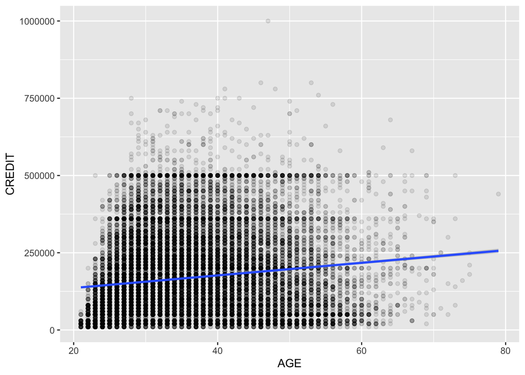

```r
ggplot(ccdata, aes(x = AGE, y = CREDIT)) +
  geom_point(alpha=0.1) +
  geom_smooth(method="lm")
```

```r
ccdata_credit_by_age <- ccdata %>%
  summarize(
    correlation = cor(AGE,CREDIT),
    n = n()
  )

knitr::kable(ccdata_credit_by_age)
```

| correlation | n |
| --- | --- |
| 0.1447128 | 30000 |

The visualization shows that older people have higher credit on average than younger people. However, the scatterplot reveals that there are significantly fewer observations (n) for older people than younger people, meaning that the averages for higher age ranges are heavily skewed by outliers. Additionally, there is a very low but still positive correlation between age and credit.

# Trivariate Data

## Age, Credit, and Education

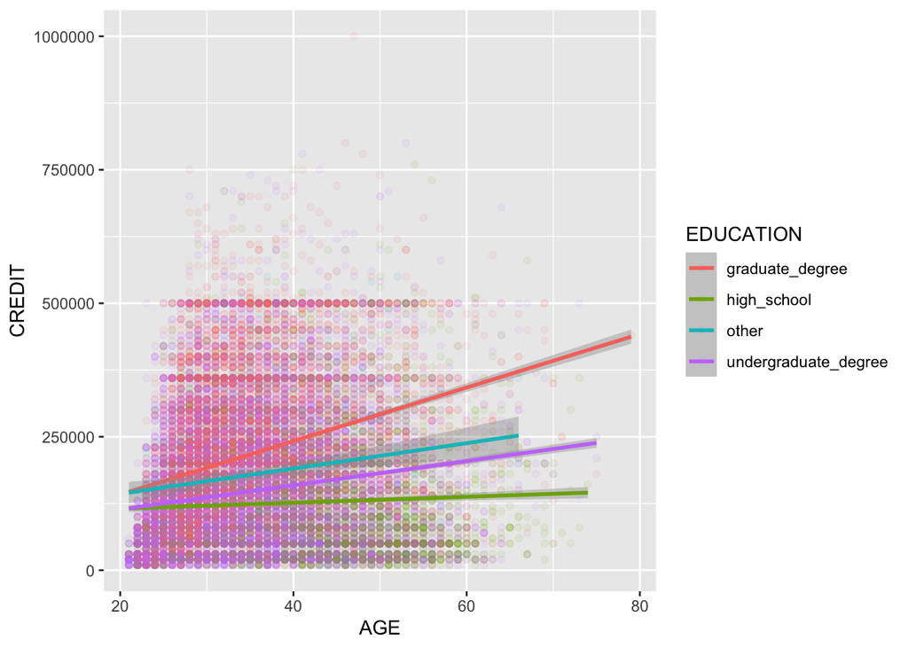

```r
ggplot(ccdata, aes(x = AGE, y = CREDIT,color=EDUCATION)) +
  geom_point(alpha=0.075) +
  geom_smooth(method="lm")
```

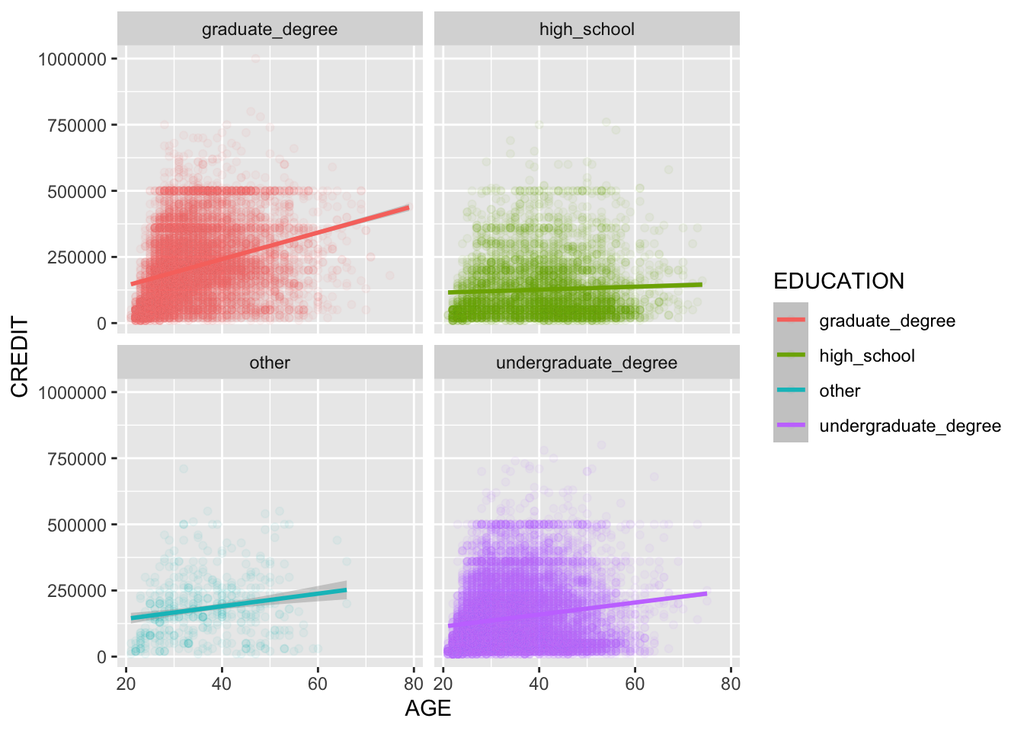

```r
ggplot(ccdata, aes(x = AGE, y = CREDIT,color=EDUCATION)) +
  geom_point(alpha=0.05) +
  geom_smooth(method="lm") +
  facet_wrap(~EDUCATION)
```

```r
ccdata_credit_by_age_ed <- ccdata %>%
  group_by(EDUCATION) %>%
  summarize(
    correlation = cor(AGE,CREDIT),
    n = n()
  )

knitr::kable(ccdata_credit_by_age_ed)
```

| EDUCATION | correlation | n |
| --- | --- | --- |
| graduate_degree | 0.3060402 | 10585 |
| high_school | 0.0510126 | 4917 |
| other | 0.1869229 | 468 |
| undergraduate_degree | 0.1672185 | 14030 |

# Conclusion

This analysis of the “Default of Credit Card Clients” dataset reveals that there is a correlation between higher levels of education and higher credit limits for individuals in Taiwan. As individuals begin to take on credit at younger ages, they start on average at a lower limit, but over time as they age, their respective limits increase at different rates. Individuals with more education at a later age will have, on average, a higher credit limit than individuals with a lower level of education.